# Image Colorizer Explained

## Basics of Computer Vision

- Before we dig into nuts and bolts of neural networks and the convolutional neural network model that we have built for our capstone project. It would be beneficial to briefly explain how it is that images are consumed by computers.
- Over millions of years the human eye has evolved to be able to easily identify objects, but computers do not have that advantage.
- Images are stored in computers as an array of pixels. Take a quick look at the below image, the 10x10 box represents an image and each box within this represents a different pixel of the image, which is characterised by its (x,y) location.
- These pixels each have a corresponding value, if the image is in grayscale format then the image only has one channel and the value of the pixel will be a single number somewhere in the range of 0-255.
- If however the images are coloured, the image contains three channels (red, green, and blue), for coloured images there will be three values in the range of 0-255 for each pixel.

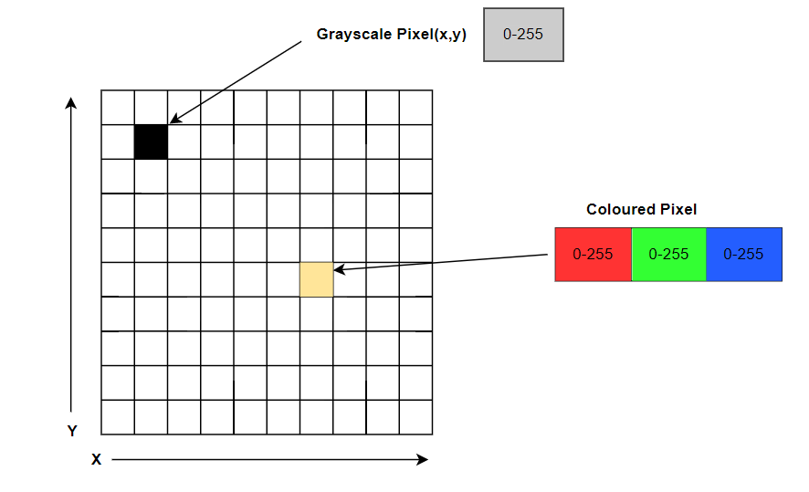

- The below graphic shows an image from the digits library that comes with sci-kit learn. This library contains images of hand-written digits and is popular for learning about computer vision.
- On the left is the array of pixel values, on the right is the same array rendered as an image, displaying the number zero.
- If you look at that array on the left you can make out the shape of a zero. This highlights at a foundational level how the differences in pixel values are read by a computer.

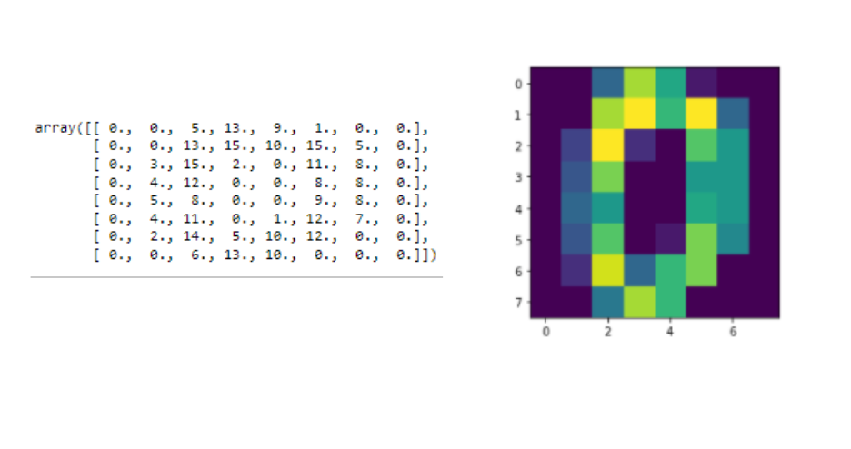

## Artificial Neural Networks

### A Neuron

- The inspiration for artificial neural networks comes from studies of the human brain. While they are not a perfect match, they have many similarities such as interconnectivity, activations and neurons.
- The below image shows a comparison of a real brain neuron and an artificial neuron.
- Roughly speaking, dendrites are the input structure of the brain neuron, the nucleus is where calculations take place and the axon is the channel for output.
- Similarly, an artificial neuron takes inputs, makes a calculation based on the sum of the inputs multiplied by their weights and adds a bias term. The result is passed into an activation function and the output is generated.

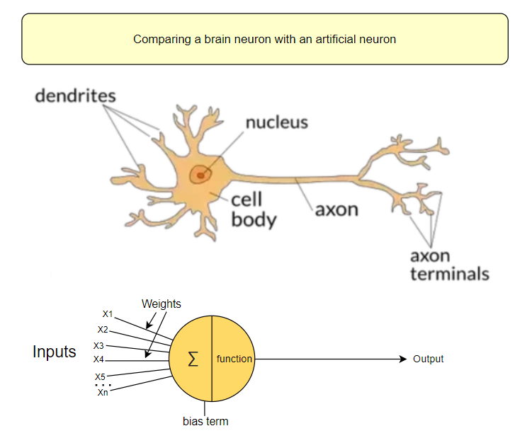

- On their own, a single neuron is essentially useless. It is when a network of them is built, usually with hundreds or thousands of other neurons that they produce results and relationships that outperform many machine learning models.

### Basic Neural Network

- A neural network consists of an input layer, an output layer and a number of hidden layers in between.
- The input layer represents the data that you feed into the network, this could be for example variables that effect the pricing of a house, or in our case the pixel values of an image.
- The output layer is what is returned from the network. In a simple binary classification problem this could be as simple as classifiying an image as being of a dog or a cat.
- In order to figure out how to calculate the value of reach of the neurons in the hidden layer, we need to understand perameters. These are weights and biases.
  - The connections between each of the neurons represent weights and each neuron has a single bias term.
- So, to calculate the value of each neuron (in the hidden layers), so far the calculations goes like this, we take the input values of the connected input layer, multiply them by their corresponding weight and sum them all together, then we add the bias term.

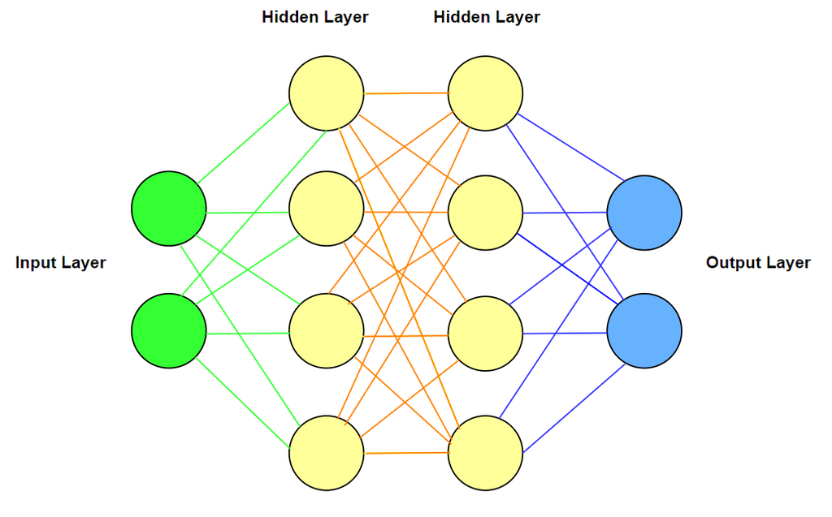

- In the below graphic we can see how the calculation of the top neuron of the first hidden layer would be calculated given a value of 1 and 2 for the input values and 0.5 and 0.6 for the weight parameters.
- This is called the dot product calculation. Basically, the dot product is the summation of all the inputs multiplied by their corresponding weight.
- At this point a bias term would be added to the values, the purpose of this is to offset the value, when combined with an activation function (which will be discussed next) this can help to model non-linear real-world problems.

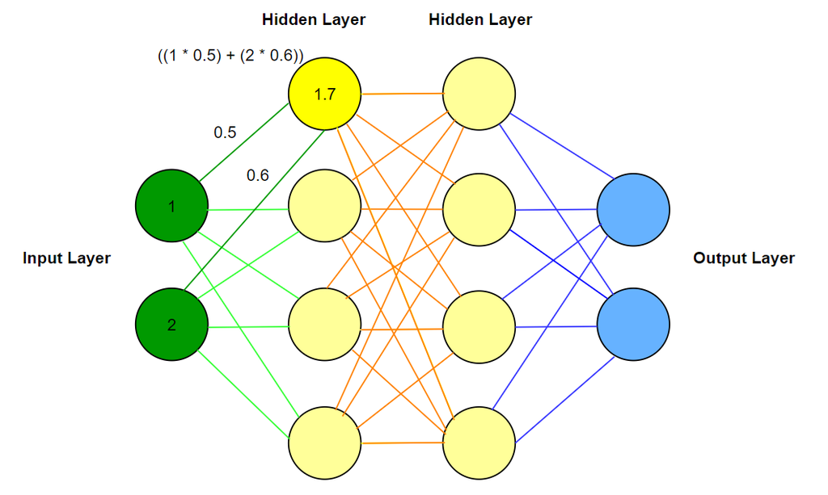

- The below graphics show a simple visual depiction of passing an image through a neural network and getting a classification.
- As the image is passed through the network it's features are learned, this enables the parameters (weights & biases) to be tweaked, learning the underlying relationships and classifying the image.

[figure not shown]

### Activation Functions

- Up to this point we have learned about neurons, basic networks and parameters such as weights and biases.
- We have also discussed how a neuron's value is calculated. Calculating the dot product for all its inputs multiplied by their weights and adding the bias term for each neuron.
- The next feature which we need to now look at are activation fuctions. These are functions that are applied to the value of a neuron with the purpose of modifying its output.
- We use activation functions because if the activation function is non linear, then it enables the neural network to map non linear functions, allowing for the solving of difficult real-world problems.
- In general a neural network will use two activation functions, one for the hidden layers and a different one for the output layer.

#### Examples of popular activation functions are described below:

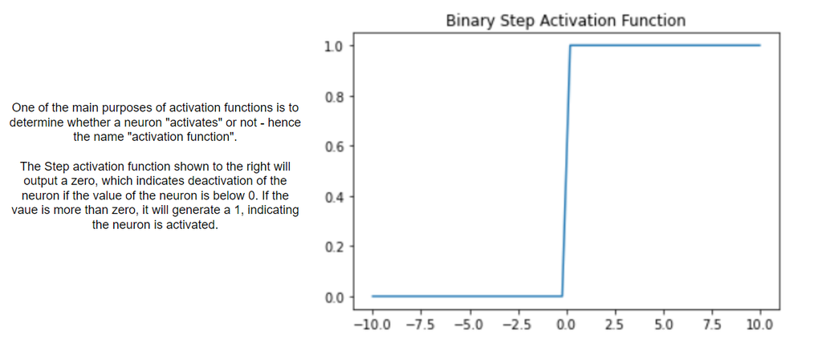

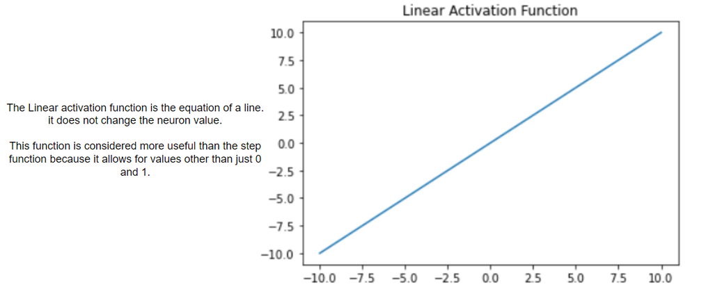

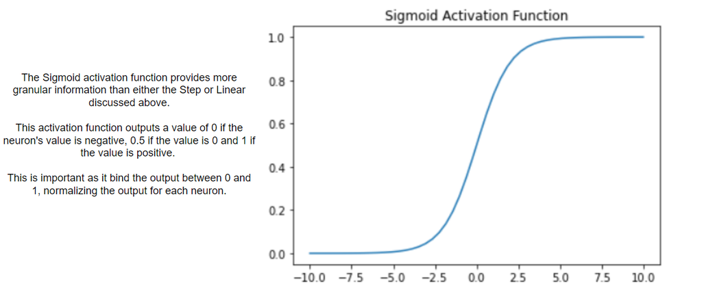

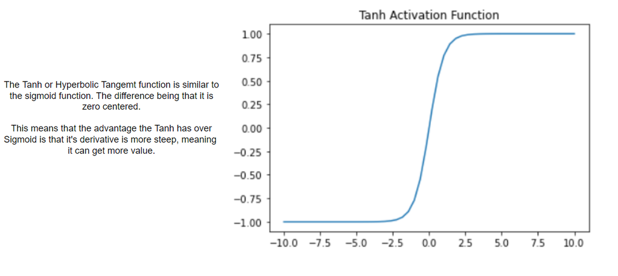

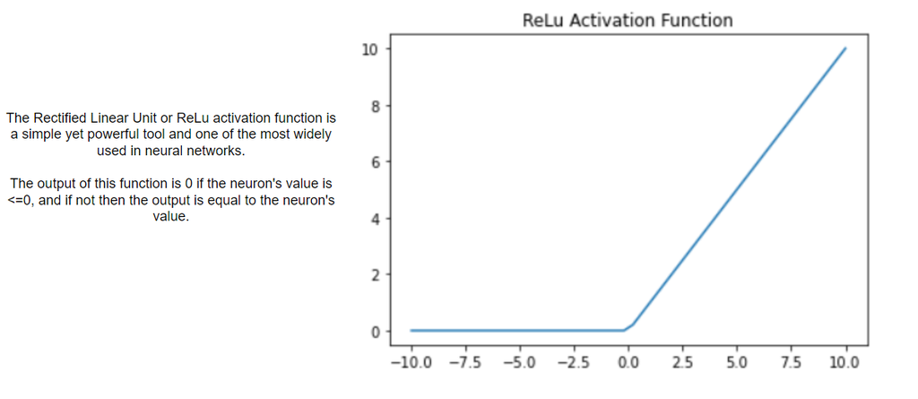

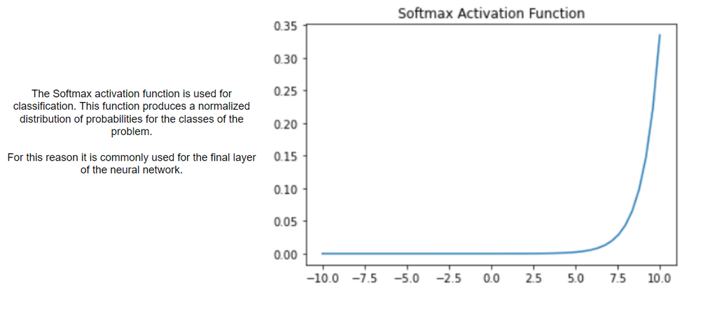

## Convolutional Neural Networks

- A convolutional neural network is a type of artificial neural network that is very popular with computer vision problems.
- A CNN combines the aspects of artificial neural networks that were discussed above, with kernel convolutions.
- A kernel convolution is a process where a small grid of numbers is taken and passed over an entire image, transforming the image based on what those numbers are.
- Kernel convolutions are used to perform image effects such as blurs, filters and edge detection.

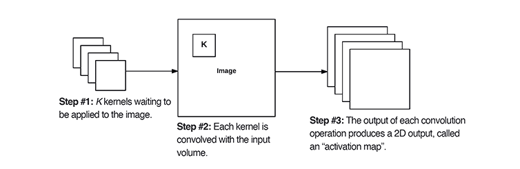

### The role of Convolutions in Deep Learning

Convolutions are effective techniques when combined with neural networks because:

- They can detect edges in images from raw pixel data in the first layer
- They use these edges to detect shapes or blobs in the second layer
- They use these shapes to detect higher-level features in the highest layers of the network

#### A visual depiction of a Convolutional Neural Network to classify images is shown below:

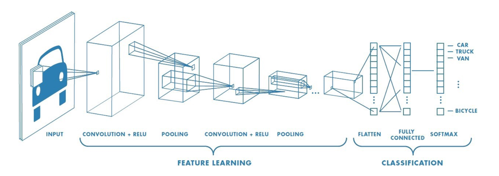

#### Zhang et Al. Colorful Image Colorization model Architecture

- The below image shows the CNN architecture developed by Zhang et al. in their paper "Colorful Image Colorization".
- This is the CNN which we have implemented in Python and trained for ourselves.
- The model architecture is depicted below, it consists of eight convolutional layers, the activation function utilized for the layers is the ReLu function.
- The output layer generates a probability distribution for all predicted classes (in this case pixel values) using the softmax activation function.
- The output layer is essentially predicting the colour values for the imput grayscale images, the L channel is then added back to the predicted AB channels, and the final image prediction is generated.

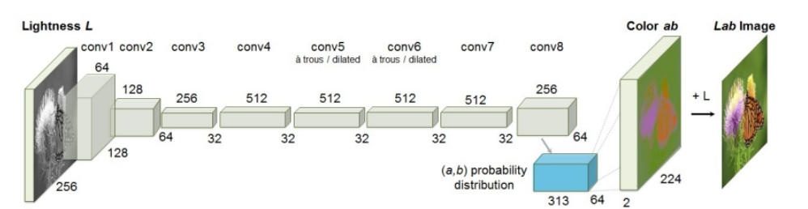

### References

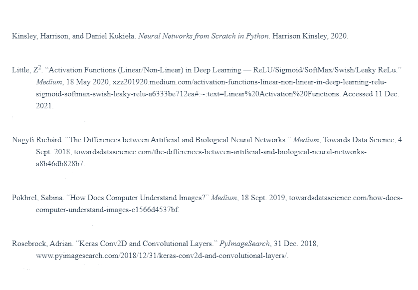